# The Effectiveness of Three-Dimensional Technology in Medical education and Training A Data scientist approach

Lamar Lyons

Georgia Institute of Technology  
llyons8@gatech.edu

#AUTHOR’S KEYWORDS: “3D anatomy”; “three dimensional anatomical”; “3D virtualization” ;“3D VR” ;“3D anatomical model”; “3D medical education”

#Load the packages

# Introduction

Anatomy is a discipline by which spatial visualization is of value. Therefore, the potential to envision and mentally manipulate 3D anatomical structures and sufficiently identify related components is an essential ability for medical students. Research in this particular field might not just assess visual-spatial abilities of a student but also demonstrate the improvements in educational technology in medical training. Going forward, some data analysis techniques will be implemented to provide a better picture of the status quo of 3D Medical education. This paper outlines the effectiveness of the 3D technology used for pedagogical purposes.

#REUSABLE FUNCTIONS

```r
Descriptive_analysis<-function(mydata){
describe(mydata)
#summary(unlist(mydata))
stat.desc(mydata)
describe(mydata)
str(mydata)
dim(mydata)
names(mydata)}

CountPerc<-function(category1){
category1<-as.factor(category1)
t<-table(category1)
p<-prop.table(t)*100

cbind(sort(t),sort(p),2)
plot(p)
}
correlation<-function(numercial,numerical2){cor(numercial,numerical2)}
Two_way_tables<-function(category1,category2){
readgender <- table(category1,category2)
readgender
addmargins(readgender) # Adding row/col margins
prop.table(readgender,1) # Row proportions
round(prop.table(readgender,1), 2) # Round col prop to 2 digits
round(100*prop.table(readgender,1), 2) # Round col prop to 2 digits (percents)
addmargins(round(prop.table(readgender,1), 2),2) # Round col prop to 2 digits
prop.table(readgender,2) # Column proportions
round(prop.table(readgender,2), 2) # Round column prop to 2 digits
round(100*prop.table(readgender,2), 2) # Round column prop to 2 digits (percents)
addmargins(round(prop.table(readgender,2), 2),1) # Round col prop to 2 digits
prop.table(readgender) # Tot proportions
round(prop.table(readgender),2) # Tot proportions rounded
round(100*prop.table(readgender),2) # Tot proportions rounded
chisq.test(readgender) # Do chisq test Ho: no relathionship


assocstats(readgender) # First two are assoc measures, last three show degree of association.
}
three_way_crosstabs<-function(Read,Major,Gender,mydata){
table3 <- xtabs(~Read+Major+Gender, data=mydata)
table3
ftable(table3a)}

Two_category_boxplot<-function(category1,category2,dataframe){
  category1<- (category1)
  category2 <- (category2)

boxplot(category1 ~ category2,
        data = dataframe,
        ylab = "",
        xlab = "",
        col = (c("pink","blue")))
dev.copy(png, file="plot1.png", width=480, height=480)
        dev.off()
        cat("MERSQI.png has been saved in", getwd())
}

CountPerc<-function(category1){
category1<-as.factor(category1)
t<-table(category1)
p<-prop.table(t)*100
plot(p)
cbind(sort(t),sort(p),2)
}
```

#MERSQI The Medical Education Research Study Quality Instrument (MERSQI) and the Newcastle-Ottawa Scale-Education (NOS-E) were created to appraise methodological quality in healthcare training research. The research aim was evaluating the interrater dependability, normative scores, along with between instrument correlation for these 2 instruments.The utilization of the MERSQI in this particular study uses the analysis by Reed et al[3]. plus was performed in the following stages: First, 3 evaluators (the writer and 2 research assistants) analyzed using the instrument and practiced the use of its independently to assess the research of those included. Third, the thirty studies had been rated independently by the 3 evaluators with the MERSQI scoring hand. #MERSQI Data Summary

```r
summary(MERSQI)
```

```
##  MERSQI item           Domain           Studies no.    Item possible score
##  Length:23          Length:23          Min.   : 0.00   Min.   :0.000
##  Class :character   Class :character   1st Qu.: 5.50   1st Qu.:1.000
##  Mode  :character   Mode  :character   Median :12.00   Median :1.000
##                                        Mean   :11.74   Mean   :1.261
##                                        3rd Qu.:17.00   3rd Qu.:1.750
##                                        Max.   :30.00   Max.   :3.000
##  Percentage (%)
##  Min.   :  0.00
##  1st Qu.: 18.30
##  Median : 40.00
##  Mean   : 39.11
##  3rd Qu.: 56.65
##  Max.   :100.00
```

```r
CountPerc(MERSQI$Domain)
```

```
##                                   [,1]      [,2] [,3]
## Complexity of analysis               2  8.695652    2
## Content                              2  8.695652    2
## Data analysis                        2  8.695652    2
## Relationships to other variable      2  8.695652    2
## Type of data                         2  8.695652    2
## Validity of evaluation instrument    2  8.695652    2
## Sampling                             3 13.043478    2
## Outcome                              4 17.391304    2
## Study design                         4 17.391304    2
```

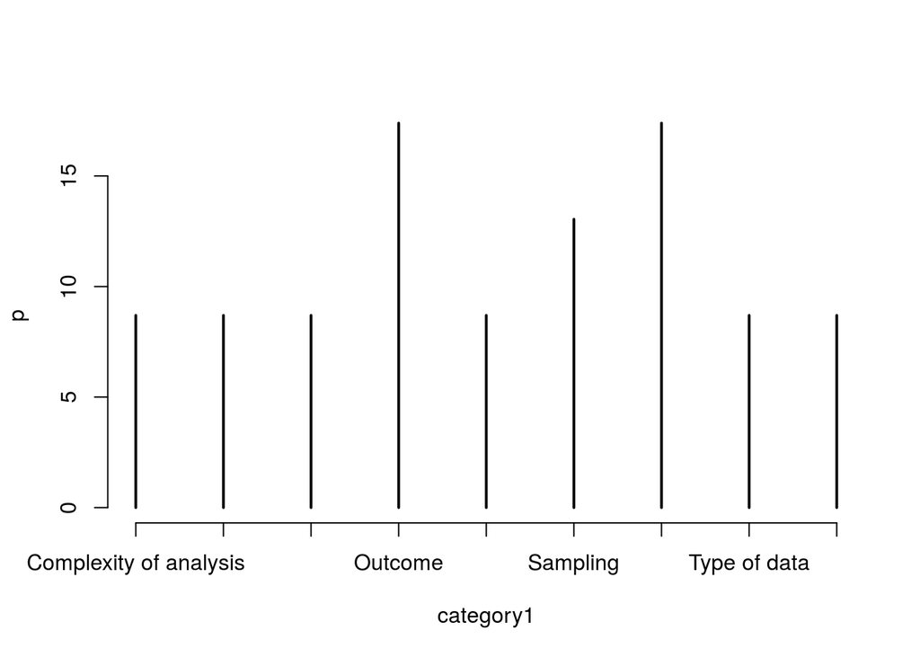

```
##        V1              V2               V3
##  Min.   :2.000   Min.   : 8.696   Min.   :2
##  1st Qu.:2.000   1st Qu.: 8.696   1st Qu.:2
##  Median :2.000   Median : 8.696   Median :2
##  Mean   :2.556   Mean   :11.111   Mean   :2
##  3rd Qu.:3.000   3rd Qu.:13.043   3rd Qu.:2
##  Max.   :4.000   Max.   :17.391   Max.   :2
```

```r
(summary(CountPerc(MERSQI$Domain)))
```

```r
Descriptive_analysis(MERSQI)
```

[output not shown]

```
## [1] "MERSQI item"         "Domain"              "Studies no."
## [4] "Item possible score" "Percentage (%)"
```

#MERSQI:Exploratory analysis

```r
head(MERSQI,3)
```

| MERSQI item | Domain | Studies no. | Item possible score | Percentage (%) |
| --- | --- | --- | --- | --- |
| Single group crosssectional or single group posttest only | Study design | 3 | 1.0 | 10 |
| Single group pretest and posttest | Study design | 0 | 1.5 | 0 |
| Nonrandomized, 2 (or more) groups | Study design | 12 | 2.0 | 40 |